# Danish Kings, W10 assignment

Christian Reinholdt

16.5.2025

## Setup

```r
knitr::opts_chunk$set(echo = TRUE, message = TRUE, warning = FALSE)
```

- Installing some packages first (change eval=TRUE, if packages are needed)

```r
options(repos = c(CRAN = "https://cloud.r-project.org"))
install.packages("tidyverse")
install.packages("tidyverse")
install.packages("dplyr")
install.packages("readr")
install.packages("ggplot2")
```

- When packages are already installed:

The task here is to load your Danish Monarchs csv into R using the `tidyverse` toolkit, calculate and explore the kings’ duration of reign with pipes `%>%` in `dplyr` and plot it over time.

## Load the kings

Make sure to first create an `.Rproj` workspace with a `data/` folder where you place either your own dataset or the provided `kings.csv` dataset.

1. Look at the dataset that are you loading and check what its columns are separated by? (hint: open it in plain text editor to see)

List what is the separator: - commas (since it is a comma separated values file (csv-file))

2. Create a `kings` object in R with the different functions below and inspect the different outputs. `read.csv()` `read_csv()` `read.csv2()` `read_csv2()`

```r
# FILL IN THE CODE BELOW and review the outputs

kings1 <- read.csv("data/kings data.csv")

kings2 <- read_csv("data/kings data.csv")
kings3 <- read.csv2("data/kings data.csv")

kings4 <- read_csv2( "data/kings data.csv")
```

```
## ℹ Using "','" as decimal and "'.'" as grouping mark. Use `read_delim()` for more control.
```

Answer: 1. Which of these functions is a `tidyverse` function? Read data with it below into a `kings` object - “_” and “.” is a tidyverse function.

```r
kings <- read_csv("data/kings data.csv")
```

2. What is the result of running `class()` on the `kings` object created with a tidyverse function.

```r
class(kings)
```

```
## [1] "spec_tbl_df" "tbl_df"      "tbl"         "data.frame"
```

- We see that “class()” informs us that the “kings” object is a tabular data.frame.
3. How many columns does the object have when created with these different functions?
- It differs, when using a proper tidyverse function to load the csv, the object has 11 columns. But when loading the csv improperly, it only has 1 column.
4. Show the dataset so that we can see how R interprets each column

```r
glimpse(kings)
```

```
## Rows: 57
## Columns: 11
## $ Name       <chr> "Gorm den Gamle", "Harald 1. Blåtand", "Toke_Gormsen", "Sve…
## $ House      <chr> "Gorm", "Gorm", "Gorm", "Gorm", "Gorm", "Gorm", "Gorm", "Fa…
## $ Start_year <chr> "936", "NULL", "985", "NULL", "1014", "1018", "1035", "1042…
## $ End_year   <chr> "958", "NULL", "986", "NULL", "1018", "1035", "1042", "1047…
## $ Birth_year <chr> "908", "936", "NULL", "NULL", "963", "NULL", "995", "1018",…
## $ Death_year <chr> "958", "985", "986", "1014", "NULL", "1035", "1042", "1047"…
## $ Gender     <chr> "M", "M", "M", "M", "M", "M", "M", "M", "M", "M", "M", "M",…
## $ Dynasty    <chr> "Jellingdynastiet", "Jellingdynastiet", "Jellingdynastiet",…
## $ Source     <chr> "https://da.wikipedia.org/wiki/Gorm_den_Gamle", "https://da…
## $ BirthDMY   <chr> "908", "936", NA, "17/04/963", "994", "995", "1018", "1024"…
## $ DeathDMY   <chr> "958", "987", NA, "03/02/1014", "1018", "12/11/1035", "08/0…
```

We see that R interprets each column as “characters”, that is, as letters, and not for instance as numbers or years.

## Calculate the duration of reign for all the kings in your table

You can calculate the duration of reign in years with `mutate` function by subtracting the equivalents of your `startReign` from `endReign` columns and writing the result to a new column called `duration`. But first you need to check a few things:

Is your data messy? Fix it before re-importing to R

- Data is not messy, since it is Adelas :-) I will however change how Rstudio interprets these columns, to be numeric.

```r
kings <- kings %>%
  mutate(
    Name = as.character(Name),
    House = as.character(House),
    Start_year = as.numeric(Start_year),
    End_year = as.numeric(End_year),
    Birth_year = as.numeric(Birth_year),
    Death_year = as.numeric(Death_year),
    Gender = as.character(Gender),
    Dynasty = as.character(Dynasty),
    Source = as.character(Source),
    BirthDMY = as.character(BirthDMY),
    DeathDMY = as.character(DeathDMY)
  ) %>%
  filter(
    !is.na(Start_year),
    !is.na(End_year)
  )
```

```r
kings_cleaned <- kings %>%
  mutate(duration = End_year - Start_year)
```

## Calculate the average duration of reign for all rulers

Do you remember how to calculate an average on a vector object? If not, review the last two lessons and remember that a column is basically a vector. So you need to subset your `kings` dataset to the `duration` column. If you subset it as a vector you can calculate average on it with `mean()` base-R function. If you subset it as a tibble, you can calculate average on it with `summarize()` tidyverse function. Try both ways!

You first need to know how to select the relevant `duration` column. What are your options? Is your selected `duration` column a tibble or a vector? The `mean()` function can only be run on a vector. The `summarize()` function works on a tibble. Are you getting an error that there are characters in your column? Coerce your data to numbers with `as.numeric()`. Remember to handle NAs: `mean(X, na.rm=TRUE)`

```r
library(dplyr)

mean_duration <- kings_cleaned %>%
  mutate(avg_duration = mean(duration, na.rm = TRUE))

mean_duration
```

```
## # A tibble: 52 × 13
##    Name    House Start_year End_year Birth_year Death_year Gender Dynasty Source
##    <chr>   <chr>      <dbl>    <dbl>      <dbl>      <dbl> <chr>  <chr>   <chr>
##  1 Gorm d… Gorm         936      958        908        958 M      Jellin… https…
##  2 Toke_G… Gorm         985      986         NA        986 M      Jellin… https…
##  3 Harald… Gorm        1014     1018        963         NA M      Jellin… https…
##  4 Knud 1… Gorm        1018     1035         NA       1035 M      Jellin… https…
##  5 Hardek… Gorm        1035     1042        995       1042 M      Jellin… https…
##  6 Magnus… Fair…       1042     1047       1018       1047 M      Jellin… https…
##  7 Svend … Estr…       1047     1074       1024       1076 M      <NA>    https…
##  8 Harald… Estr…       1074     1080       1019       1080 M      Jellin… https…
##  9 Knud 2… Estr…       1080     1086       1041       1086 M      Jellin… https…
## 10 Oluf 1… Estr…       1086     1095       1043       1095 M      Jellin… https…
## # ℹ 42 more rows
## # ℹ 4 more variables: BirthDMY <chr>, DeathDMY <chr>, duration <dbl>,
## #   avg_duration <dbl>
```

## How many and which kings enjoyed a longer-than-average duration of reign?

You have calculated the average duration above. Use it now to `filter()` the `duration` column in `kings` dataset. Display the result and also count the resulting rows with `count()`

```r
long_reign_kings <- kings_cleaned %>%
  filter(duration > 19.577)

print(long_reign_kings)
```

```
## # A tibble: 25 × 12
##    Name    House Start_year End_year Birth_year Death_year Gender Dynasty Source
##    <chr>   <chr>      <dbl>    <dbl>      <dbl>      <dbl> <chr>  <chr>   <chr>
##  1 Gorm d… Gorm         936      958        908        958 M      Jellin… https…
##  2 Svend … Estr…       1047     1074       1024       1076 M      <NA>    https…
##  3 Niels   Estr…       1104     1134       1055       1134 M      Jellin… https…
##  4 Valdem… Estr…       1157     1182       1131       1182 M      Jellin… https…
##  5 Knud 4. Estr…       1182     1202       1163       1202 M      Jellin… https…
##  6 Valdem… Estr…       1202     1241       1170       1241 M      Jellin… https…
##  7 Erik 5… Estr…       1259     1286       1249       1286 M      Jellin… https…
##  8 Erik 6… Estr…       1286     1319       1274       1319 M      Jellin… https…
##  9 Valdem… Estr…       1340     1375       1320       1375 M      Jellin… https…
## 10 Erik 7… Pome…       1396     1439       1382       1459 M      Jellin… https…
## # ℹ 15 more rows
## # ℹ 3 more variables: BirthDMY <chr>, DeathDMY <chr>, duration <dbl>
```

```r
long_reign_kings %>%
  count()
```

```
## # A tibble: 1 × 1
##       n
##   <int>
## 1    25
```

```r
view(long_reign_kings)
```

We see here a list of 25 kings (and queens) who had longer than average duration of reign.

## How many days did the three longest-ruling monarchs rule?

Sort kings by reign `duration` in the descending order. Select the three longest-ruling monarchs with the `slice()` function Use `mutate()` to create `Days` column where you calculate the total number of days they ruled BONUS: consider the transition year (with 366 days) in your calculation!

```r
kings_cleaned %>%
  arrange(desc(duration)) %>%
  slice(1:3) %>%
  mutate(
    Days = duration * 365.25,
    Days = Days
  ) %>%
  select(Name, duration, Days)
```

```
## # A tibble: 3 × 3
##   Name               duration   Days
##   <chr>                 <dbl>  <dbl>
## 1 Christian 4.             60 21915
## 2 Margrete 2.              51 18628.
## 3 Erik 7. af Pommern       43 15706.
```

## Challenge: Plot the kings’ duration of reign through time

What is the long-term trend in the duration of reign among Danish monarchs? How does it relate to the historical violence trends ?

Try to plot the duration of reign column in `ggplot` with `geom_point()` and `geom_smooth()` In order to peg the duration (which is between 1-99) somewhere to the x axis with individual centuries, I recommend creating a new column `midyear` by adding to `startYear` the product of `endYear` minus the `startYear` divided by two (`startYear + (endYear-startYear)/2`). Now you can plot the kings dataset, plotting `midyear` along the x axis and `duration` along y axis BONUS: add a title, nice axis labels to the plot and make the theme B&W and font bigger to make it nice and legible!

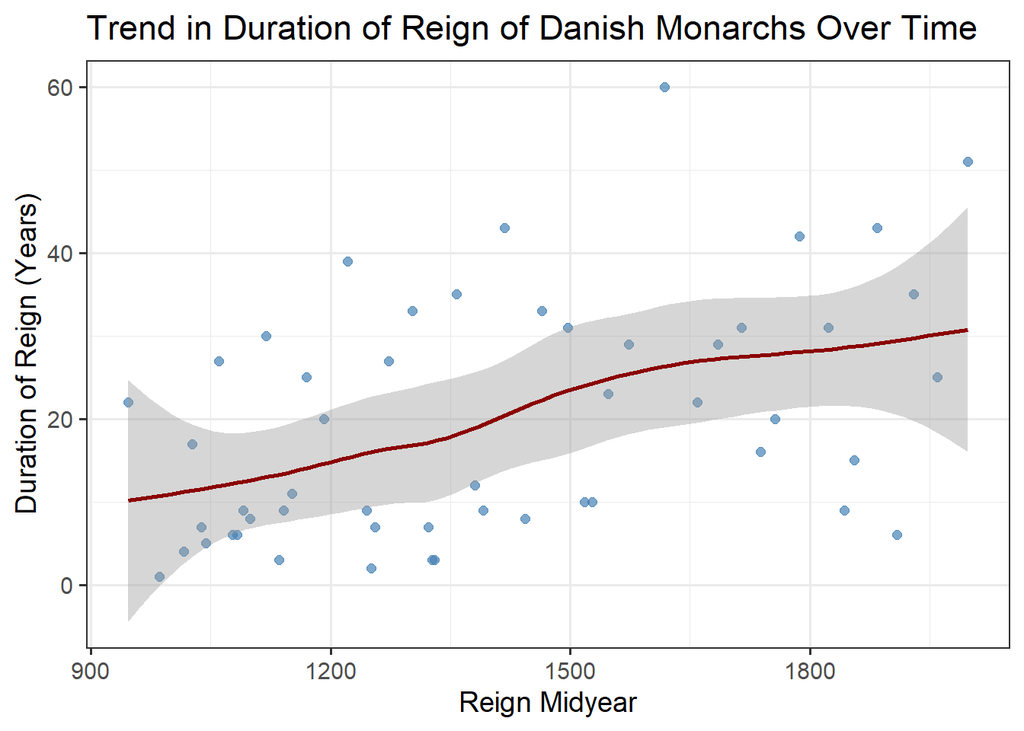

```r
kings_cleaned <- kings_cleaned %>%
  mutate(midyear = Start_year + (End_year - Start_year) / 2)

ggplot(kings_cleaned, aes(x = midyear, y = duration)) +
  geom_point(color = "steelblue", size = 2, alpha = 0.7) +
  geom_smooth(method = "loess", se = TRUE, color = "darkred") +
  labs(
    title = "Trend in Duration of Reign of Danish Monarchs Over Time",
    x = "Reign Midyear",
    y = "Duration of Reign (Years)"
  ) +
  theme_bw(base_size = 14)
```

The long term trend in the duration of Danish Monarchs is that they rule for longer. The average increases from something like 10 years to something like 30 years in the entire period. This goes well with general violence trends in history, which very often see violence decrease over time.